# Final Project: Job Recommender

### Introduction: This project will build a very basic job recommendation system using a content-based approach.

#### Purpose 1: In this project, we present a recommender system designed for the job seeker in Data Science. The proposed recommender system aims at leveraging the jobs and companies that are important for a target candidate. To meet this objective, job descriptions and candidate resumes are examined along with other user inputs. The recommendation approach is modeled on content-based analysis using natural language processing. The dataset consisted of scraped job postings from [Glassdoor](http://www.glassdoor.com) and resumes from [Post Resumes Free](https://www.postjobfree.com/resume/adktqz/senior-data-scientist-brooklyn-ny)

#### Purpose 2: The second purpose is to provide the job seeker information about their qualifications in relation to Data Scientists in industry. In 2018, Kaggle conducted a survey to gather information on the state of data science and machine learning around the world. A total of 23,859 responses were collected and was compiled for analysis and the raw data can be found via https://www.kaggle.com/kaggle/kaggle-survey-2018?select=SurveySchema.csv. The candidate’s resume is compared against this dataset to understand what compensation could be expected based on the type and number of Data Science related skills.

##### Approach: We have applied the following process to organize our workflow:

1. Business Understanding
2. Data Understanding
3. Data Preparation
4. Modeling
5. Evaluation
6. Integration and Deployment

# Instructions

This project is a proof-of-concept(POC) with certain assumptions on the data. For this implementation, Purpose 1 will be demonstrated via a markdown file below to show step by step how the text data is processed. Purpose 2 will be displayed in the Shiny App to allow the user to easily manipulate and filter settings to gain more insight of the job market today.

## Load the libraries

```r
library(tidyverse)
library(tidytext)
library(httr)
library(rvest)
library(stringr)
library(readr)
library(tm)
library(slam)
library(dplyr)
library(tidytext)
library(tidyr)
library(dplyr)
library(textstem)
library(lsa)
library(data.table)
library(VennDiagram)
library(wordcloud)
library(RColorBrewer)
library(ggplot2)
library(wordcloud)
library(httr)
```

# Recommender System: Cosine Similarity

## Load the data

The scraped job postings are stored in a dataframe and read in below. A sample resume is scraped and the raw text is stored in variable, “resume”.

```r
library(readr)
urlfile<-"https://raw.githubusercontent.com/baruab/Team2_Project_3_607/main/job_posting.csv"
jobs<-read_csv(url(urlfile))
#url_res<-"https://www.postjobfree.com/resume/adktqz/senior-data-scientist-brooklyn-ny"
#url_res<-"https://www.postjobfree.com/resume/adk07o/data-science-new-york-ny"
#url_res<-"https://www.postjobfree.com/resume/adol8d/data-scientist-new-york-ny"
#url_res<-"https://www.postjobfree.com/resume/adost3/data-scientist-new-york-ny"
url_res<-"https://www.postjobfree.com/resume/adonl3/data-scientist-charlotte-nc"
#url_res<-"https://www.postjobfree.com/resume/ado61j/data-scientist-arlington-va"
#url_res<-"https://www.postjobfree.com/resume/adol8d/data-scientist-new-york-ny"
web<- read_html(url_res)
resume<-web %>%html_nodes(".normalText")%>%html_text()
head(jobs)
```

```
## # A tibble: 6 x 13
##    ...1 job_title job_description min_salary max_salary city  state company_name
##   <dbl> <chr>     <chr>                <dbl>      <dbl> <chr> <chr> <chr>
## 1     1 Data Sci~ "Polypore Inte~      71310     122975 Char~ NC    Polypore In~
## 2     2 Data Sci~ "Key Responsib~         NA         NA Not ~ MA    Van Pool Tr~
## 3     3 Data Sci~ "The Challenge~      69795     111477 Norf~ VA    Booz Allen ~
## 4     4 Senior D~ "Position Summ~      75217     121211 Beac~ OH    Penske
## 5     5 Data Sci~ "The kind of p~      74839     112212 Newt~ MA    Paytronix S~
## 6     6 Data Sci~ "The Data Scie~      80867     133796 Trum~ CT    HPOne
## # ... with 5 more variables: company_industry <chr>, company_rating <dbl>,
## #   bachelors <dbl>, masters <dbl>, phd <dbl>
```

```r
head(resume)
```

```
## [1] "\r\n\t\t\t\t\tNicholas Kim\r\nData Scientist\r\nP: 980-***-****\r\nG: adonl3@r.postjobfree.com\r\nPROFESSIONAL SUMMARY\r\nData Scientist with 7+ years’ experience processing and analyzing data across a variety of industries. Leverages various mathematical, statistical, and Machine Learning t…
```

## Subsetting the data

A total of 2527 Data Science related Job postings are available for the candidate to consider. However, 300 are evaluated here to save on computation time. The job descriptions are stored as raw text in a new dataframe, “des_all”.

```r
##Multiple Job postings at once (Corpus)
#One row of posting
postings<-300
des_all<-subset(jobs,select=c(3))
#des_all<-data.frame(jobs$job_description)
des_all<-des_all[1:postings,]
head(des_all)
```

```
## # A tibble: 6 x 1
##   job_description
##   <chr>
## 1 "Polypore International, an Asahi Kasei Group Company, is a leading technolog~
## 2 "Key Responsibilities: Beacon is seeking a Data Scientist to join the organiz~
## 3 "The Challenge: Are you excited at the prospect of unlocking the secrets held~
## 4 "Position Summary As a Senior Data Scientist, you develop the next generation~
## 5 "The kind of person we're looking for: We're looking for an energetic, though~
## 6 "The Data Scientist is responsible for collecting, cleaning, translating data~
```

## Cleaning The Text

The variable “resume”, which contains the resume text file is stored as the last row of the des_all dataframe (after all the job postings are listed in preceding rows). In preparation for NLP, the text is processed by: 1) Using regular expressions, unnecesssary symbols and notations are removed. 2) Stop words are removed. 3) All letters are brought to lower case. 4) Punctuations are removed. 5) Each string is lemmatized to bring to its basic form.

```r
#adding resume text as doc_id last
des_all<-rbind(des_all,resume)
des_all$job_description<-des_all$job_description%>%
  str_replace_all(pattern="\n",replacement=" ")%>%
  str_replace_all(pattern="www+|com|@\\S+|#\\S+|http|\\*|\\s[A-Z]\\s|\\s[a-z]\\s|\\d|�+",replacement=" ")
des_all$job_description<-tolower(des_all$job_description)
des_all$job_description<-removeNumbers(des_all$job_description)
des_all$job_description<-removePunctuation(des_all$job_description)
#des_all$job_description<-stripWhitespace(des_all$job_description)
des_all$job_description<-removeWords(des_all$job_description,stopwords("en"))
des_all$job_description<-sapply(des_all$job_description,lemmatize_strings)
head(des_all)
```

```
## # A tibble: 6 x 1
##   job_description
##   <chr>
## 1 polypore international asahi kasei group company lead technology pany special~
## 2 key responsibility beacon seek datum scientist join organization serve key pl~
## 3 challenge excite prospect unlock secret hold datum set fascinate possibility ~
## 4 position summary senior datum scientist develop next generation supply chain ~
## 5 kind person look look energetic thoughtful intelligent creative thinker join ~
## 6 datum scientist responsible collect clean translate datum meet panys need eve~
```

## Term Matrix

The job descriptions are stored in a Volatile Corpus and the words are tokenized into a matrix. The term frequency per job description is recorded in the matrix and the terms are weighted using term frequency-inverse document frequency (tfidf). The tfidf offsets the number of times a term appears in a document by the number of documents in the corpous that contain the word. This ensures that terms that simply appear more times than others are not incorrectly considered to be significant since a term can simply appear more frequently if a document has more text.

```r
des_all_df<-data.frame(
  doc_id=1:(postings+1),
  text=des_all$job_description
)
Corpus=VCorpus(DataframeSource(des_all_df))
tf<-DocumentTermMatrix(Corpus,control=list(weighting=weightTf))
tfidf<-DocumentTermMatrix(Corpus,control=list(weighting=weightTfIdf))
inspect(tf)
```

```
## <<DocumentTermMatrix (documents: 301, terms: 8883)>>
## Non-/sparse entries: 62137/2611646
## Sparsity           : 98%
## Maximal term length: 73
## Weighting          : term frequency (tf)
## Sample             :
##      Terms
## Docs  business datum experience learn model science team use will work
##   100        2    17          5     0     0       4    3   5    6   16
##   121        0    17          8    10     4       5    9   0   10    8
##   179        3    34          1     4     2       5    1   8   12    5
##   232        4    15         10     3     9       4    6   1    2    8
##   268        5     7         10     2     1       2    5   1    1   16
##   301        5    34          5    16    38       3    6  27    0    8
##   62         2    16          5     6     5       4    4   0    7    5
##   63         0    43         16     7     3      34    3   5   14    7
##   91         0    13          7     2     5       1    7   7    4   10
##   98         6    12          3     3     5       2    4   7    4    4
```

```r
inspect(tfidf)
```

```
## <<DocumentTermMatrix (documents: 301, terms: 8883)>>
## Non-/sparse entries: 62137/2611646
## Sparsity           : 98%
## Maximal term length: 73
## Weighting          : term frequency - inverse document frequency (normalized) (tf-idf)
## Sample             :
##      Terms
## Docs     business      covid        datum     health        hire       model
##   120 0.000000000 0.00000000 0.0008532882 0.00000000 0.000000000 0.000000000
##   15  0.000000000 0.00000000 0.0025206677 0.00000000 0.000000000 0.000000000
##   195 0.000000000 0.00000000 0.0011771435 0.00000000 0.000000000 0.000000000
##   232 0.004337884 0.00000000 0.0040408740 0.00000000 0.000000000 0.008921024
##   242 0.000000000 0.00000000 0.0015782057 0.00000000 0.000000000 0.001935666
##   275 0.000000000 0.00000000 0.0047983114 0.00000000 0.008572608 0.000000000
##   34  0.000000000 0.02430545 0.0003998593 0.00000000 0.000000000 0.000000000
##   53  0.000000000 0.00000000 0.0022669988 0.00000000 0.008100388 0.000000000
##   54  0.000000000 0.00000000 0.0040531191 0.02728102 0.000000000 0.007456714
##   68  0.000000000 0.00000000 0.0034968087 0.00000000 0.000000000 0.000000000
##      Terms
## Docs         pany     product response surge
##   120 0.000000000 0.009251992        0     0
##   15  0.005885090 0.003416372        0     0
##   195 0.010993271 0.000000000        0     0
##   232 0.001257916 0.000000000        0     0
##   242 0.004912922 0.000000000        0     0
##   275 0.000000000 0.004335575        0     0
##   34  0.001867131 0.000000000        0     0
##   53  0.000000000 0.000000000        0     0
##   54  0.000000000 0.000000000        0     0
##   68  0.000000000 0.000000000        0     0
```

## TF-IDF Cosine Similarity

The similarity between job descriptions of each job posting to the candidates resume is assessed using cosine similarity. Mathematically, the cosine similarity measures the cosine of the angle between two vectors projected. The closer the output is to 1, the more similar the objects are. The lsa package is used to calculate the cosine matrix. Since the resume text is stored in the last row of the matrix, the last row of the cosine similarity output will compare the resume to all the job postings.

```r
#test cosine
tfidf_a<-as.matrix(tfidf)
tfidf_a<-transpose(data.frame(tfidf_a))
tfidf_a<-as.matrix(tfidf_a)
cos_df<-data.frame(cosine(tfidf_a))
resume_similarity<-cos_df[(postings+1),]
head(resume_similarity)
```

[output not shown]

[output cut: 41 more lines]

```
## V301 0.0521297 0.037593 0.1020849 0.0006584202 0.03857487 0.02910581 0.04502476
##            V262       V263      V264       V265       V266      V267       V268
## V301 0.07302718 0.09399763 0.1483487 0.01220999 0.03864722 0.1076212 0.08008692
##            V269       V270       V271       V272       V273       V274
## V301 0.02862698 0.09645855 0.05278978 0.05334496 0.05514225 0.03865138
##           V275       V276         V277       V278       V279       V280
## V301 0.0264474 0.08242506 0.0006584202 0.06504287 0.03591798 0.09838319
##           V281     V282      V283         V284       V285       V286       V287
## V301 0.0611253 0.147724 0.1261354 0.0006584202 0.03095455 0.04303923 0.03662237
##            V288       V289         V290       V291       V292       V293
## V301 0.02654855 0.05788278 0.0006584202 0.09938876 0.07476916 0.06727576
##            V294         V295       V296       V297       V298       V299
## V301 0.04089304 0.0006584202 0.06449686 0.05204562 0.04311112 0.05768125
##           V300 V301
## V301 0.1519766    1
```

## Recommendation Dataframe

The job posting dataframe is re-arranged based on the cosine similarity output. As the row number increases, the lower the similarity between the resume and job posting. The new dataframe is called “rec_df”.

```r
list<-names(resume_similarity)<-NULL
list<-unlist(c(resume_similarity))
order<-order(list,decreasing=TRUE)
order<-order[-c(1)]
doc_ID<-data.frame(order)
rec_df<-doc_ID
colnames(rec_df)<-c("doc_ID")
rec_df<-rec_df%>%
  mutate(job_title=jobs[order,2])%>%
  mutate(min_salary=jobs[order,4])%>%
  mutate(max_salary=jobs[order,5])%>%
  mutate(city=jobs[order,6])%>%
  mutate(state=jobs[order,7])%>%
  mutate(company_name=jobs[order,8])%>%
  mutate(company_industry=jobs[order,9])%>%
  mutate(company_rating=jobs[order,10])%>%
  mutate(bachelors=jobs[order,11])%>%
  mutate(masters=jobs[order,12])%>%
  mutate(PHD=jobs[order,13])
rec_df<-unnest(rec_df)
head(rec_df)
```

```
## # A tibble: 6 x 12
##   doc_ID job_title                 min_salary max_salary city  state company_name
##    <int> <chr>                          <dbl>      <dbl> <chr> <chr> <chr>
## 1    219 Machine Learning Engineer     122998     151838 San ~ CA    price.com
## 2    219 Data Scientist                    NA         NA Palo~ CA    Landing AI
## 3    219 Data Scientist                118964     187172 Bris~ CA    Nomis Solut~
## 4    219 Senior Data Scientist         150691     151132 Menl~ CA    Quantifind
## 5    219 Chief Data Scientist              NA         NA Remo~ Remo~ Espire Serv~
## 6    219 Data Scientist II                 NA         NA San ~ CA    EDI Special~
## # ... with 5 more variables: company_industry <chr>, company_rating <dbl>,
## #   bachelors <dbl>, masters <dbl>, PHD <dbl>
```

## Visualization

```r
#understanding the terms that are most relevant
rec<-function(ranking){
row_num<-ranking+1
z<-data.frame(as.matrix(tfidf))
compare1<-rbind(z[ranking,],z[nrow(z),])
comp1<-compare1%>%
  mutate(row_n=1:n())%>%
  select_if(function(x) any(x!=0 & .$row_n!=0))
comp1_t<-transpose(comp1)
colnames(comp1_t)<-c("Resume","Job")
comp1_t$terms<-colnames(comp1)
comp1_matches<-comp1_t[comp1_t$Resume!=0 & comp1_t$Job!=0,]
rownames(comp1_matches)<-NULL
comp1_matches<-comp1_matches[-c(nrow(comp1_matches)),]
comp1_matches_n<-nrow(comp1_matches)
Job1_diff<-comp1_t[comp1_t$Resume==0 & comp1_t$Job!=0,]
Job1_diff_n<-nrow(Job1_diff)
Resume1_diff<-comp1_t[comp1_t$Resume!=0 & comp1_t$Job==0,]
Resume1_diff_n<-nrow(Resume1_diff)
#Venn Diagram of common and different words between resume and job posting.
grid.newpage()
draw.pairwise.venn(Resume1_diff_n+comp1_matches_n, Job1_diff_n+comp1_matches_n, comp1_matches_n, category = c("Terms in your resume", "Terms in Job Posting"), lty = rep("blank",
    2), fill = c("light blue", "pink"), alpha = rep(0.5, 2), cat.pos = c(0,
    0), cat.dist = rep(0.025, 2), scaled = FALSE)
#Word Cloud for top recommended job
comp1_matches_adjust<-comp1_matches%>%
  mutate(comp1_matches$Job*1000)
colnames(comp1_matches_adjust)<-c("Resume","Job","terms","adjust")
set.seed(1234)
wordcloud(words = comp1_matches_adjust$terms, freq = comp1_matches_adjust$adjust, min.freq = 1,
          max.words=200, random.order=FALSE, rot.per=0.35,
          colors=brewer.pal(8, "Dark2"))
return(rec_df[ranking,2:9])
}
```

## Test cases

rec(1) is the output of the top recommended job posting. rec(2) and rec(3) are the second and third.

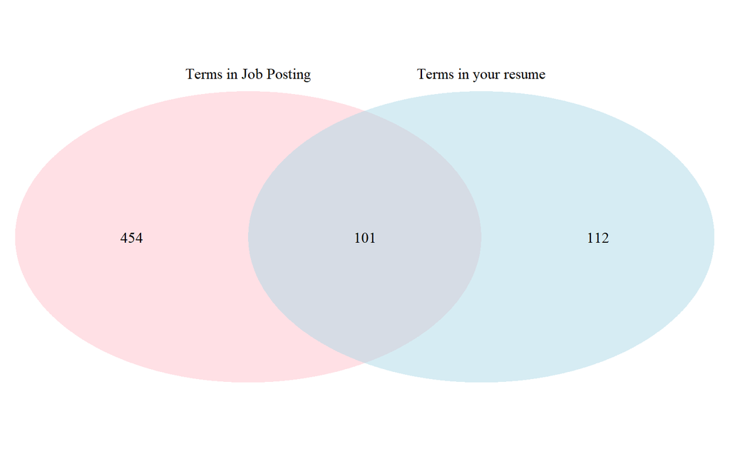

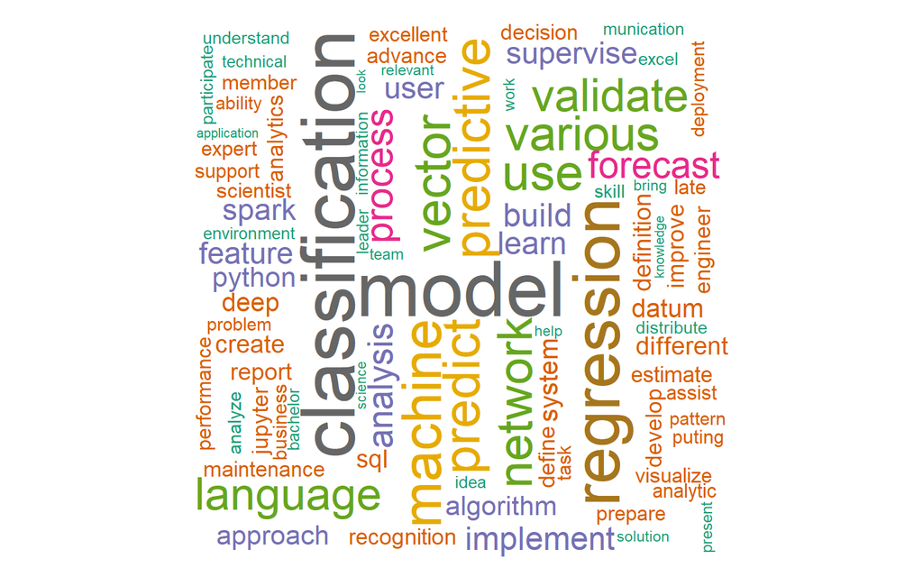

```
## # A tibble: 1 x 8
##   job_title     min_salary max_salary city   state company_name company_industry
##   <chr>              <dbl>      <dbl> <chr>  <chr> <chr>        <chr>
## 1 Machine Lear~     122998     151838 San F~ CA    price.com    <NA>
## # ... with 1 more variable: company_rating <dbl>
```

```r
rec(1)
```

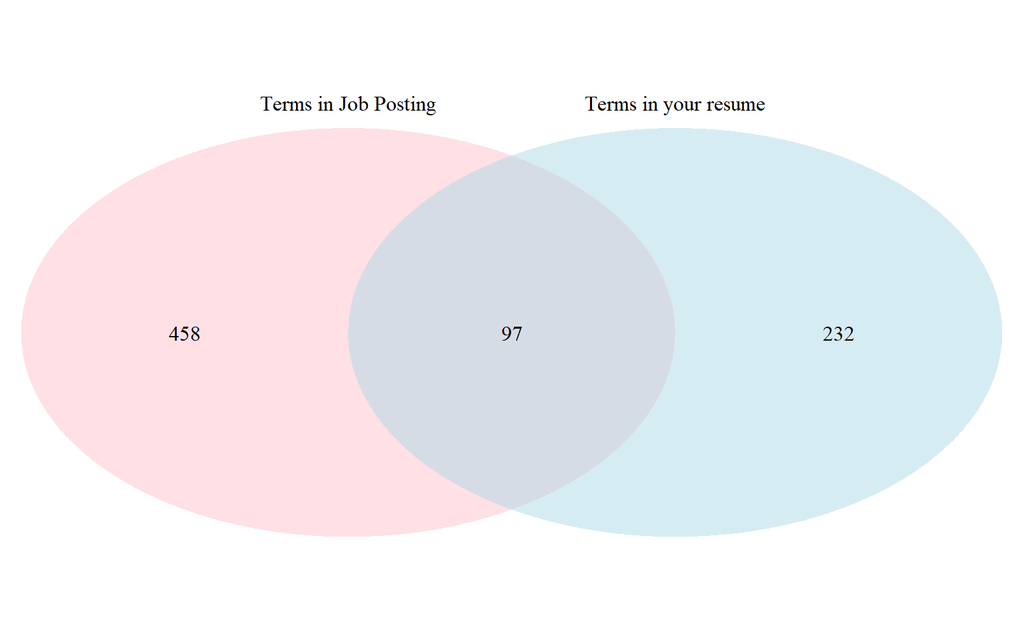

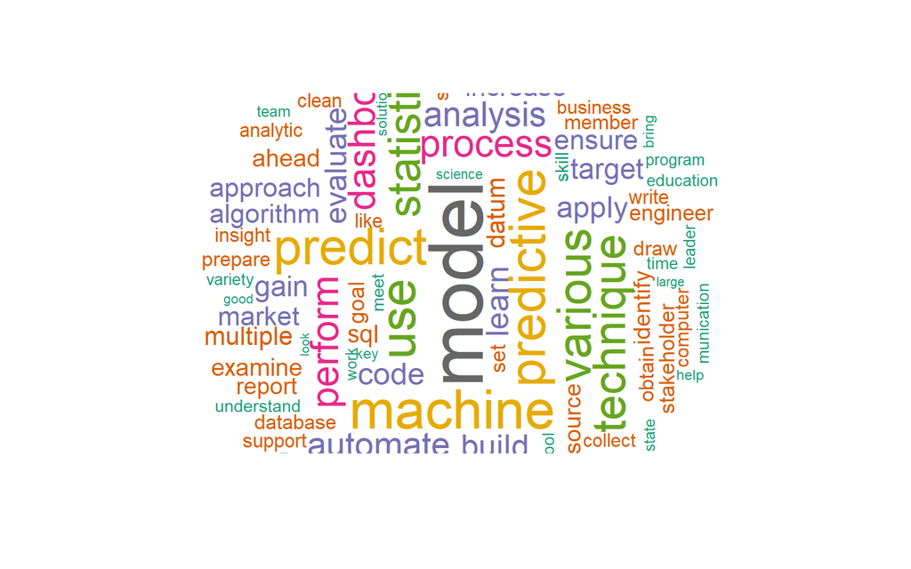

```
## # A tibble: 1 x 8
##   job_title      min_salary max_salary city      state company_name company_industry
##   <chr>               <dbl>      <dbl> <chr>     <chr> <chr>        <chr>
## 1 Data Scientist         NA         NA Palo Alto CA    Landing AI   Information Tec~
## # ... with 1 more variable: company_rating <dbl>
```

```r
rec(2)
```